# Projet_Customer_Churn

Présentation du Projet : Prédiction de la Résiliation des Clients (Customer Churn)

*L'objectif de ce projet est d'analyser et de prédire le départ des clients (« churn ») d'une entreprise de télécommunications à partir de leurs caractéristiques et comportements. En prédisant les clients susceptibles de partir, l'entreprise peut prendre des mesures pour améliorer leur fidélité*.

Présentation des Données

```python
#importation des modules
import numpy as np #numpy
import pandas as pd #pandas
import seaborn as sns #seaborn
import matplotlib.pyplot as plt
```

```python
import warnings
warnings.simplefilter(action='ignore', category=FutureWarning)
```

```python
df=pd.read_csv("WA_Fn-UseC_-Telco-Customer-Churn.csv")
```

```python
df.head()
```

|  | customerID | gender | SeniorCitizen | Partner | Dependents | tenure | PhoneService | MultipleLines | InternetService | OnlineSecurity | ... | DeviceProtection | TechSupport | StreamingTV | StreamingMovies | Contract | PaperlessBilling | PaymentMethod | MonthlyCharges | TotalCharges | Churn |
| --- | --- | --- | --- | --- | --- | --- | --- | --- | --- | --- | --- | --- | --- | --- | --- | --- | --- | --- | --- | --- | --- |
| 0 | 7590-VHVEG | Female | 0 | Yes | No | 1 | No | No phone service | DSL | No | ... | No | No | No | No | Month-to-month | Yes | Electronic check | 29.85 | 29.85 | No |
| 1 | 5575-GNVDE | Male | 0 | No | No | 34 | Yes | No | DSL | Yes | ... | Yes | No | No | No | One year | No | Mailed check | 56.95 | 1889.5 | No |
| 2 | 3668-QPYBK | Male | 0 | No | No | 2 | Yes | No | DSL | Yes | ... | No | No | No | No | Month-to-month | Yes | Mailed check | 53.85 | 108.15 | Yes |
| 3 | 7795-CFOCW | Male | 0 | No | No | 45 | No | No phone service | DSL | Yes | ... | Yes | Yes | No | No | One year | No | Bank transfer (automatic) | 42.30 | 1840.75 | No |
| 4 | 9237-HQITU | Female | 0 | No | No | 2 | Yes | No | Fiber optic | No | ... | No | No | No | No | Month-to-month | Yes | Electronic check | 70.70 | 151.65 | Yes |

5 rows × 21 columns

```python
df.describe()
```

|  | SeniorCitizen | tenure | MonthlyCharges |
| --- | --- | --- | --- |
| count | 7043.000000 | 7043.000000 | 7043.000000 |
| mean | 0.162147 | 32.371149 | 64.761692 |
| std | 0.368612 | 24.559481 | 30.090047 |
| min | 0.000000 | 0.000000 | 18.250000 |
| 25% | 0.000000 | 9.000000 | 35.500000 |
| 50% | 0.000000 | 29.000000 | 70.350000 |
| 75% | 0.000000 | 55.000000 | 89.850000 |
| max | 1.000000 | 72.000000 | 118.750000 |

```python
print(df.shape,df.size)
```

```
(7043, 21) 147903
```

```python
df.dropna()
```

|  | customerID | gender | SeniorCitizen | Partner | Dependents | tenure | PhoneService | MultipleLines | InternetService | OnlineSecurity | ... | DeviceProtection | TechSupport | StreamingTV | StreamingMovies | Contract | PaperlessBilling | PaymentMethod | MonthlyCharges | TotalCharges | Churn |
| --- | --- | --- | --- | --- | --- | --- | --- | --- | --- | --- | --- | --- | --- | --- | --- | --- | --- | --- | --- | --- | --- |
| 0 | 7590-VHVEG | Female | 0 | Yes | No | 1 | No | No phone service | DSL | No | ... | No | No | No | No | Month-to-month | Yes | Electronic check | 29.85 | 29.85 | No |
| 1 | 5575-GNVDE | Male | 0 | No | No | 34 | Yes | No | DSL | Yes | ... | Yes | No | No | No | One year | No | Mailed check | 56.95 | 1889.5 | No |
| 2 | 3668-QPYBK | Male | 0 | No | No | 2 | Yes | No | DSL | Yes | ... | No | No | No | No | Month-to-month | Yes | Mailed check | 53.85 | 108.15 | Yes |
| 3 | 7795-CFOCW | Male | 0 | No | No | 45 | No | No phone service | DSL | Yes | ... | Yes | Yes | No | No | One year | No | Bank transfer (automatic) | 42.30 | 1840.75 | No |
| 4 | 9237-HQITU | Female | 0 | No | No | 2 | Yes | No | Fiber optic | No | ... | No | No | No | No | Month-to-month | Yes | Electronic check | 70.70 | 151.65 | Yes |
| ... | ... | ... | ... | ... | ... | ... | ... | ... | ... | ... | ... | ... | ... | ... | ... | ... | ... | ... | ... | ... | ... |
| 7038 | 6840-RESVB | Male | 0 | Yes | Yes | 24 | Yes | Yes | DSL | Yes | ... | Yes | Yes | Yes | Yes | One year | Yes | Mailed check | 84.80 | 1990.5 | No |
| 7039 | 2234-XADUH | Female | 0 | Yes | Yes | 72 | Yes | Yes | Fiber optic | No | ... | Yes | No | Yes | Yes | One year | Yes | Credit card (automatic) | 103.20 | 7362.9 | No |
| 7040 | 4801-JZAZL | Female | 0 | Yes | Yes | 11 | No | No phone service | DSL | Yes | ... | No | No | No | No | Month-to-month | Yes | Electronic check | 29.60 | 346.45 | No |
| 7041 | 8361-LTMKD | Male | 1 | Yes | No | 4 | Yes | Yes | Fiber optic | No | ... | No | No | No | No | Month-to-month | Yes | Mailed check | 74.40 | 306.6 | Yes |
| 7042 | 3186-AJIEK | Male | 0 | No | No | 66 | Yes | No | Fiber optic | Yes | ... | Yes | Yes | Yes | Yes | Two year | Yes | Bank transfer (automatic) | 105.65 | 6844.5 | No |

7043 rows × 21 columns

Prétraitement et visualisation des données

**Avant d'entraîner un modèle, les étapes suivantes ont été réalisées** : *Gestion des valeurs manquantes : Remplacement des valeurs manquantes de TotalCharges par la médiane, Encodage des variables catégoriques : Transformation en variables binaires (« one-hot encoding »), Standardisation des variables numériques : Normalisation des montants et durées, Division du jeu de données : 80% pour l'entraînement, 20% pour le test*

```python
# Supprimer la colonne 'customerID' qui n'est pas utile
df.drop(columns=['customerID'], inplace=True)

# Convertir 'TotalCharges' en numérique en forçant les erreurs à NaN
df['TotalCharges'] = pd.to_numeric(df['TotalCharges'], errors='coerce')

# Vérifier les valeurs manquantes
missing_values = df.isnull().sum()

# Afficher les colonnes avec des valeurs manquantes
missing_values[missing_values > 0]
```

```
TotalCharges    11
dtype: int64
```

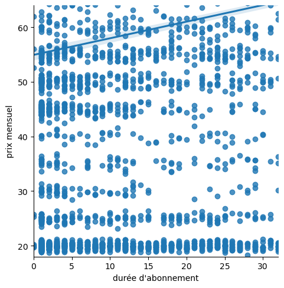

```python
sns.lmplot(data=df,x='tenure',y='MonthlyCharges')
plt.xlabel("durée d'abonnement")
plt.ylabel('prix mensuel')
plt.xlim(0,32)
plt.ylim(18,64)
plt.show()
```

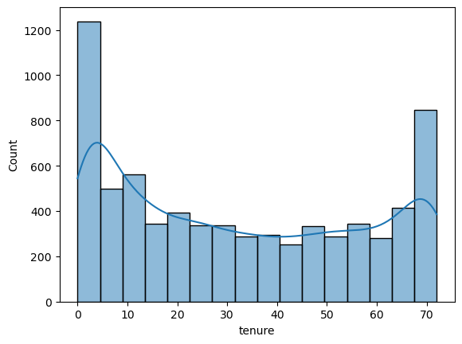

```python
sns.histplot(data=df['tenure'],kde=True) #histogramme du variable tenure
```

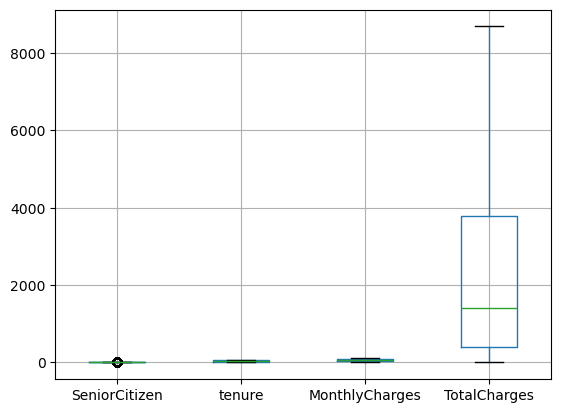

```python
df.boxplot()
```

```python
df_encoded = pd.get_dummies(df, drop_first=True)#encodage des variables qualitatives
```

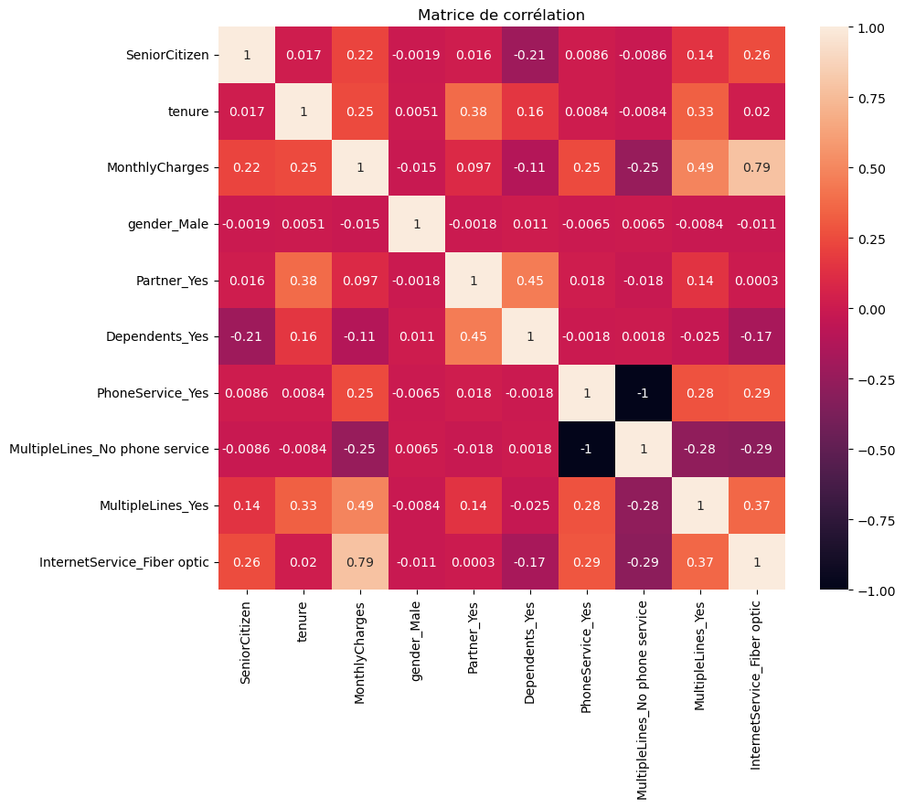

```python
#traçons le diagramme de corrélation
# Heatmap de corrélation pour les variables numériques
d_encoded=d_encoded.iloc[:,:10]
plt.figure(figsize=(10, 8))
sns.heatmap(d_encoded.corr(), annot=True)
plt.title("Matrice de corrélation")
plt.show()
```

Modélisation des variables

*Nous avons utilisé la Régression Logistique pour prédire la résiliation des clients* :

```python
from sklearn.model_selection import train_test_split
from sklearn.preprocessing import StandardScaler, LabelEncoder

# Remplacer les valeurs manquantes par la médiane
df['TotalCharges'] = df['TotalCharges'].fillna(df['TotalCharges'].median())


# Séparer les caractéristiques (X) et la cible (y)
X = df.drop(columns=['Churn'])
y = df['Churn']

# Encoder la variable cible (Yes -> 1, No -> 0)
label_encoder = LabelEncoder()
y = label_encoder.fit_transform(y)

# Identifier les variables catégoriques
categorical_features = X.select_dtypes(include=['object']).columns

# Appliquer l'encodage one-hot pour les variables catégoriques
X_encoded = pd.get_dummies(X, columns=categorical_features, drop_first=True)

# Standardiser les variables numériques
scaler = StandardScaler()
numerical_features = ['tenure', 'MonthlyCharges', 'TotalCharges']
X_encoded[numerical_features] = scaler.fit_transform(X_encoded[numerical_features])

# Diviser les données en ensemble d'entraînement et de test
X_train, X_test, y_train, y_test = train_test_split(X_encoded, y, test_size=0.2, random_state=42, stratify=y)

# Vérifier la forme des ensembles
X_train.shape, X_test.shape, y_train.shape, y_test.shape
```

```
((5634, 30), (1409, 30), (5634,), (1409,))
```

```python
from sklearn.linear_model import LogisticRegression
model = LogisticRegression(max_iter=1000)
model.fit(X_train, y_train)
```

```
LogisticRegression(max_iter=1000)
```

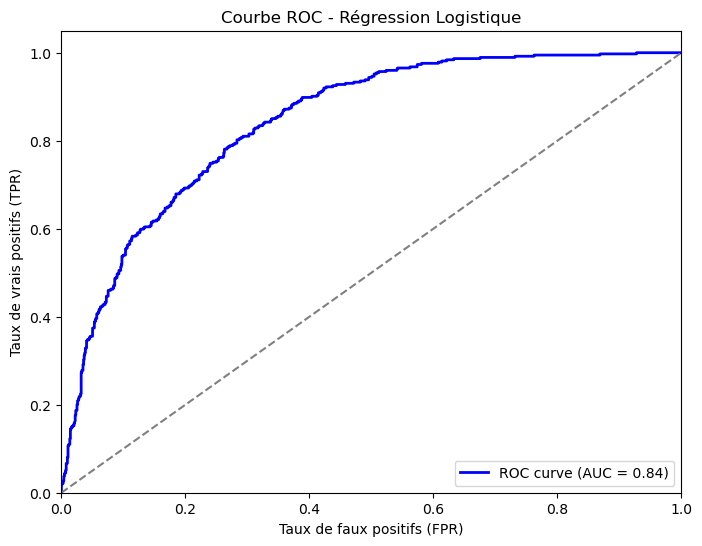

```python
import matplotlib.pyplot as plt
import seaborn as sns
from sklearn.metrics import roc_curve, auc

# Calcul des probabilités pour la courbe ROC
y_probs = model.predict_proba(X_test)[:, 1]  # Probabilité d'appartenance à la classe 1
fpr, tpr, _ = roc_curve(y_test, y_probs)
roc_auc = auc(fpr, tpr)

# Tracé de la courbe ROC
plt.figure(figsize=(8, 6))
plt.plot(fpr, tpr, color='blue', lw=2, label=f'ROC curve (AUC = {roc_auc:.2f})')
plt.plot([0, 1], [0, 1], color='gray', linestyle='--')  # Courbe aléatoire
plt.xlim([0.0, 1.0])
plt.ylim([0.0, 1.05])
plt.xlabel('Taux de faux positifs (FPR)')
plt.ylabel('Taux de vrais positifs (TPR)')
plt.title('Courbe ROC - Régression Logistique')
plt.legend(loc="lower right")
plt.show()
```

Recommandations

*Pour réduire le churn, l'entreprise peut* :

**Offrir des réductions aux clients à risque**.

**Améliorer les services Internet et TV pour accroître la satisfaction**.

**Encourager des abonnements longue durée avec des offres attractives**.